# Project Report

# Project Question2:

Here, we created layers of transaction using the bin selection in histogram. After creating layers, we computed a feature in every layer. We selected number of transactions as feature. Then we computed the number of transaction happened at a particular day for a particular layer. Also, we calculated the correlation between the feature and the token prices for every layer.

### Creating layers using bin selection of histogram

```r
#Finding out the values of interquartile range.
summary(datawithoutoutlier$tokenamount)
```

```
##      Min.   1st Qu.    Median      Mean   3rd Qu.      Max.
## 1.000e+00 4.100e+19 2.151e+20 6.778e+21 1.093e+21 8.013e+26
```

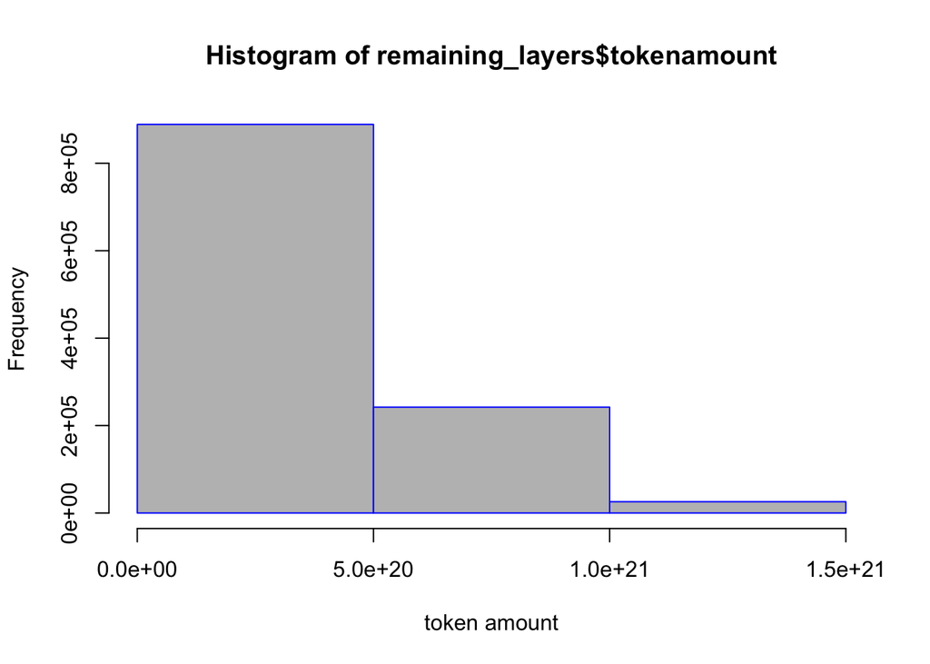

```r
#Histogram of samples from third quartile to max amount
layer1 <- datawithoutoutlier[which (datawithoutoutlier$tokenamount>=1.093e+21),]
#Histogram of samples between first to third quartile
remaining_layers <- datawithoutoutlier[which (datawithoutoutlier$tokenamount<1.093e+21 & datawithoutoutlier$tokenamount>=4.100e+19 ),]
#histogram of sample between min to first quartile.
layer5 <- datawithoutoutlier[which (datawithoutoutlier$tokenamount<4.100e+19 & datawithoutoutlier$tokenamount>=1.000e+00 ),]
#hist(remaining_layers$tokenamount, breaks = "Sturges")
hist(remaining_layers$tokenamount,  xlab="token amount", border = "blue", col ="grey", breaks = 3)
```

```r
summary(remaining_layers$tokenamount)
```

```
##      Min.   1st Qu.    Median      Mean   3rd Qu.      Max.
## 4.100e+19 1.000e+20 2.151e+20 3.279e+20 4.993e+20 1.093e+21
```

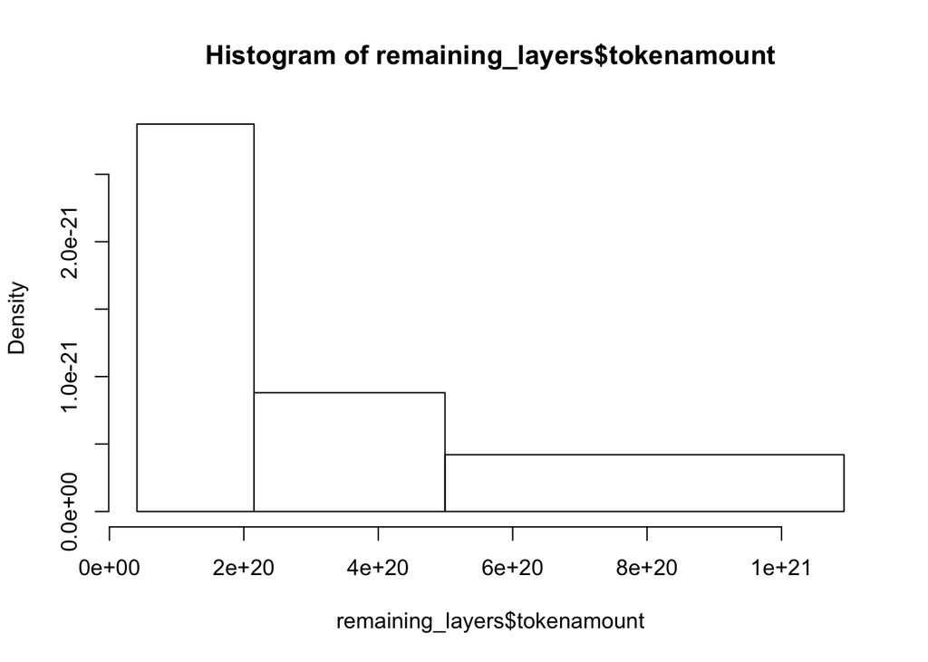

```r
breakpoints = c(4.100e+19, 2.151e+20, 4.993e+20, 1.093e+21)
hist(remaining_layers$tokenamount, breaks = breakpoints)
```

```r
# Now their are 5 layers in total.
```

```r
#Now making unequal bin size 3 layers
layer2 <- remaining_layers[which (remaining_layers$tokenamount>=4.100e+19 & remaining_layers$tokenamount<2.151e+20 ),]
layer3 <- remaining_layers[which (remaining_layers$tokenamount>=2.151e+20 & remaining_layers$tokenamount<4.993e+20 ),]
layer4 <- remaining_layers[which (remaining_layers$tokenamount>=4.993e+20 & remaining_layers$tokenamount<1.093e+21 ),]
```

### Trial and error of finding layers using Doane’s method

```r
#Tried making histogram with the doane's formula but eventually didn't work as the number of bins are more than expected and so its difficult to extract correlation from the layers.
skew <- function(x) {
  xbar <- mean(x)
  m3 <- mean((x-xbar)^3)
  m2 <- mean((x-xbar)^2)
  return (m3/m2^1.5)
}
n <- 2313151
x <- datawithoutoutlier$tokenamount
absb1 = abs(skew(x))
se = sqrt( 6 * (n - 2)/((n + 1) * (n + 3)) )
Ke = log2( 1 + absb1/se )
nclass.Doane = ceiling( nclass.Sturges(x) + Ke )
print(nclass.Doane)
```

```
## [1] 42
```

```r
R = diff(range(x))
h.Doane = R/nclass.Doane; print(h.Doane)
```

```
## [1] 1.907809e+25
```

```r
breaks.Doane = min(x) + h.Doane*seq(0,nclass.Doane)
print(round(breaks.Doane))
```

```
##  [1] 1.000000e+00 1.907809e+25 3.815618e+25 5.723427e+25 7.631237e+25
##  [6] 9.539046e+25 1.144685e+26 1.335466e+26 1.526247e+26 1.717028e+26
## [11] 1.907809e+26 2.098590e+26 2.289371e+26 2.480152e+26 2.670933e+26
## [16] 2.861714e+26 3.052495e+26 3.243276e+26 3.434056e+26 3.624837e+26
## [21] 3.815618e+26 4.006399e+26 4.197180e+26 4.387961e+26 4.578742e+26
## [26] 4.769523e+26 4.960304e+26 5.151085e+26 5.341866e+26 5.532646e+26
## [31] 5.723427e+26 5.914208e+26 6.104989e+26 6.295770e+26 6.486551e+26
## [36] 6.677332e+26 6.868113e+26 7.058894e+26 7.249675e+26 7.440456e+26
## [41] 7.631237e+26 7.822017e+26 8.012798e+26
```

### Converted unixtime with date and time format for every layer.

```r
#For layer1
val1 <- layer1$unixtime
layer1$unixtime <- as.POSIXct(val1, origin="1970-01-01")
layer1$unixtime = as.Date(layer1$unixtime, format = "%Y/%m/%d %I:%M:%S")
layer1$unixtime = as.Date(format(layer1$unixtime, "%Y-%m-%d"))
```

```r
# Converted unixtime with date and time format.
#For layer2
val2 <- layer2$unixtime
layer2$unixtime <- as.POSIXct(val2, origin="1970-01-01")
layer2$unixtime = as.Date(layer2$unixtime, format = "%Y/%m/%d %I:%M:%S")
layer2$unixtime = as.Date(format(layer2$unixtime, "%Y-%m-%d"))
```

```r
# Converted unixtime with date and time format.
#For layer3
val3 <- layer3$unixtime
layer3$unixtime <- as.POSIXct(val3, origin="1970-01-01")
layer3$unixtime = as.Date(layer3$unixtime, format = "%Y/%m/%d %I:%M:%S")
layer3$unixtime = as.Date(format(layer3$unixtime, "%Y-%m-%d"))
```

```r
# Converted unixtime with date and time format.
#For layer4
val4 <- layer4$unixtime
layer4$unixtime <- as.POSIXct(val4, origin="1970-01-01")
layer4$unixtime = as.Date(layer4$unixtime, format = "%Y/%m/%d %I:%M:%S")
layer4$unixtime = as.Date(format(layer4$unixtime, "%Y-%m-%d"))
```

```r
# Converted unixtime with date and time format.
#For layer5
val5 <- layer5$unixtime
layer5$unixtime <- as.POSIXct(val5, origin="1970-01-01")
layer5$unixtime = as.Date(layer5$unixtime, format = "%Y/%m/%d %I:%M:%S")
layer5$unixtime = as.Date(format(layer5$unixtime, "%Y-%m-%d"))
```

```r
my.data.frame<-layer2[which (layer2$unixtime == "2018-04-24"),]
nrow(my.data.frame)
```

```
## [1] 5798
```

```r
eos_price<- read.delim("~/Desktop/R/eos_price.txt")
eos_price$Date = format(as.Date(eos_price$Date, '%m/%d/%y'), "%m/%d/%Y")
```

### Creating a new data frame for every layer which has columns of Date, Closing price of token, frequency i.e. no of transaction occured on that particular date.

```r
# For layer1
df_2 = table(layer1["unixtime"])
final_layer1 <- as.data.frame(df_2)
colnames(final_layer1) <- c("date", "frequency")
final_layer1$date = format(as.Date(final_layer1$date, '%Y-%m-%d'), "%m/%d/%Y")
final_layer1["close_price"] <- NA

for(i in seq(1,nrow(final_layer1),1))
{
  for(j in seq(1, nrow(eos_price),1))
  {
    if(final_layer1[i, "date"] == eos_price[j, "Date"]){
      final_layer1[i, "close_price"] <- eos_price[j, "Close"]
    }
  }
}
final_layer1 <- na.omit(final_layer1)
```

```r
# For layer2
df_2 = table(layer2["unixtime"])
final_layer2 <- as.data.frame(df_2)
colnames(final_layer2) <- c("date", "frequency")
final_layer2$date = format(as.Date(final_layer2$date, '%Y-%m-%d'), "%m/%d/%Y")
final_layer2["close_price"] <- NA

for(i in seq(1,nrow(final_layer2),1))
{
  for(j in seq(1, nrow(eos_price),1))
  {
    if(final_layer2[i, "date"] == eos_price[j, "Date"]){
      final_layer2[i, "close_price"] <- eos_price[j, "Close"]
    }
  }
}
final_layer2 <- na.omit(final_layer2)
```

```r
# For layer3
df_2 = table(layer3["unixtime"])
final_layer3 <- as.data.frame(df_2)
colnames(final_layer3) <- c("date", "frequency")
final_layer3$date = format(as.Date(final_layer3$date, '%Y-%m-%d'), "%m/%d/%Y")
final_layer3["close_price"] <- NA

for(i in seq(1,nrow(final_layer3),1))
{
  for(j in seq(1, nrow(eos_price),1))
  {
    if(final_layer3[i, "date"] == eos_price[j, "Date"]){
      final_layer3[i, "close_price"] <- eos_price[j, "Close"]
    }
  }
}
final_layer3 <- na.omit(final_layer3)
```

```r
# For layer4
df_2 = table(layer4["unixtime"])
final_layer4 <- as.data.frame(df_2)
colnames(final_layer4) <- c("date", "frequency")
final_layer4$date = format(as.Date(final_layer4$date, '%Y-%m-%d'), "%m/%d/%Y")
final_layer4["close_price"] <- NA

for(i in seq(1,nrow(final_layer4),1))
{
  for(j in seq(1, nrow(eos_price),1))
  {
    if(final_layer4[i, "date"] == eos_price[j, "Date"]){
      final_layer4[i, "close_price"] <- eos_price[j, "Close"]
    }
  }
}
final_layer4 <- na.omit(final_layer4)
```

```r
# For layer5
df_2 = table(layer5["unixtime"])
final_layer5 <- as.data.frame(df_2)
colnames(final_layer5) <- c("date", "frequency")
final_layer5$date = format(as.Date(final_layer5$date, '%Y-%m-%d'), "%m/%d/%Y")
final_layer5["close_price"] <- NA

for(i in seq(1,nrow(final_layer5),1))
{
  for(j in seq(1, nrow(eos_price),1))
  {
    if(final_layer5[i, "date"] == eos_price[j, "Date"]){
      final_layer5[i, "close_price"] <- eos_price[j, "Close"]
    }
  }
}
final_layer5 <- na.omit(final_layer5)
```